# Harmonization exposition : age

This report lists the candidate variable for DataScheme variables of the construct **age**.

# Exposition

> This report is meant to be compiled after having executed the script `./manipulation/0-ellis-island.R`, which prepares the necessary data transfer object (DTO). We begin with a brief recap of this script and the DTO it produces.

## Ellis Island

> All data land on Ellis Island.

The script `0-ellis-island.R` is the first script in the analytic workflow. It accomplished the following:

- 1. Reads in raw data files from the candidate studies
- 2. Extract, combines, and exports their metadata (specifically, variable names and labels, if provided) into `./data/shared/derived/meta-data-live.csv`, which is updated every time Ellis Island script is executed.
- 3. Augments raw metadata with instructions for renaming and classifying variables. The instructions are provided as manually entered values in `./data/shared/meta-data-map.csv`. They are used by automatic scripts in later harmonization and analysis.
- 4. Combines unit and metadata into a single DTO to serve as a starting point to all subsequent analyses.

```r
# load the product of 0-ellis-island.R,  a list object containing data and metadata
dto <- readRDS("./data/unshared/derived/dto.rds")
```

```r
# the list is composed of the following elements
names(dto)
```

```
[1] "studyName" "filePath"  "unitData"  "metaData"
```

```r
# 1st element - names of the studies as character vector
dto[["studyName"]]
```

```
[1] "alsa"  "lbsl"  "satsa" "share" "tilda"
```

```r
# 2nd element - file paths of the data files for each study as character vector
dto[["filePath"]]
```

```
[1] "./data/unshared/raw/ALSA-Wave1.Final.sav"         "./data/unshared/raw/LBSL-Panel2-Wave1.Final.sav"
[3] "./data/unshared/raw/SATSA-Q3.Final.sav"           "./data/unshared/raw/SHARE-Israel-Wave1.Final.sav"
[5] "./data/unshared/raw/TILDA-Wave1.Final.sav"
```

```r
# 3rd element - list objects with the following elements
names(dto[["unitData"]])
```

```
[1] "alsa"  "lbsl"  "satsa" "share" "tilda"
```

```r
# each of these elements is a raw data set of a corresponding study, for example
dplyr::tbl_df(dto[["unitData"]][["lbsl"]])
```

```
Source: local data frame [656 x 26]

        id AGE94 SEX94  MSTAT94 EDUC94     NOWRK94  SMK94                                         SMOKE
     (int) (int) (int)   (fctr)  (int)      (fctr) (fctr)                                        (fctr)
1  4001026    68     1 divorced     16 no, retired     no                                  never smoked
2  4012015    94     2  widowed     12 no, retired     no                                  never smoked
3  4012032    94     2  widowed     20 no, retired     no don't smoke at present but smoked in the past
4  4022004    93     2       NA     NA          NA     NA                                  never smoked
5  4022026    93     2  widowed     12 no, retired     no                                  never smoked
6  4031031    92     1  married      8 no, retired     no don't smoke at present but smoked in the past
7  4031035    92     1  widowed     13 no, retired     no don't smoke at present but smoked in the past
8  4032201    92     2       NA     NA          NA     NA don't smoke at present but smoked in the past
9  4041062    91     1  widowed      7          NA     no don't smoke at present but smoked in the past
10 4042057    91     2       NA     NA          NA     NA                                            NA
..     ...   ...   ...      ...    ...         ...    ...                                           ...
Variables not shown: ALCOHOL (fctr), WINE (int), BEER (int), HARDLIQ (int), SPORT94 (int), FIT94 (int), WALK94 (int),
  SPEC94 (int), DANCE94 (int), CHORE94 (int), EXCERTOT (int), EXCERWK (int), HEIGHT94 (int), WEIGHT94 (int), HWEIGHT
  (int), HHEIGHT (int), SRHEALTH (fctr), year_of_wave (dbl)
```

### Meta

```r
# 4th element - a dataset names and labels of raw variables + added metadata for all studies
dto[["metaData"]] %>% dplyr::select(study_name, name, item, construct, type, categories, label_short, label) %>%
  DT::datatable(
    class   = 'cell-border stripe',
    caption = "This is the primary metadata file. Edit at `./data/shared/meta-data-map.csv",
    filter  = "top",
    options = list(pageLength = 6, autoWidth = TRUE)
  )
```

|  | study_name | name | item | construct | type | categories | label_short | label |
| --- | --- | --- | --- | --- | --- | --- | --- | --- |
| 1 | alsa | SEQNUM | id | id | demo | 2087 | Sequence Number | Sequence Number |
| 2 | alsa | EXRTHOUS | exertion |  | activity |  | Exertion around house | Exertion around house |
| 3 | alsa | HWMNWK2W | walking |  | activity |  | Times walked in past two weeks | Times walked in past two weeks |
| 4 | alsa | LSVEXC2W |  |  | activity |  | Less vigor sessions last 2 weeks | Less vigor sessions last 2 weeks |
| 5 | alsa | LSVIGEXC |  |  | activity |  | Less vigor past 2 weeks | Less vigor past 2 weeks |
| 6 | alsa | TMHVYEXR |  |  | activity |  | Time heavy physical exertion | Time heavy physical exertion |
| 7 | alsa | TMVEXC2W |  |  | activity |  | Vigor Time past 2 weeks | Vigor Time past 2 weeks |
| 8 | alsa | VIGEXC2W |  |  | activity |  | Vigor Sessions in past 2 weeks | Vigor Sessions in past 2 weeks |
| 9 | alsa | VIGEXCS |  |  | activity |  | Vigorous exercise | Vigorous exercise |
| 10 | alsa | WALK2WKS |  |  | activity |  | Walking past 2 weeks | Walking past 2 weeks |

[output cut: 140 more lines]

# ALSA

## AGE

```r
dto[["metaData"]] %>% dplyr::filter(study_name=="alsa", name=="AGE") %>% dplyr::select(name,label)
```

```
  name label
1  AGE   Age
```

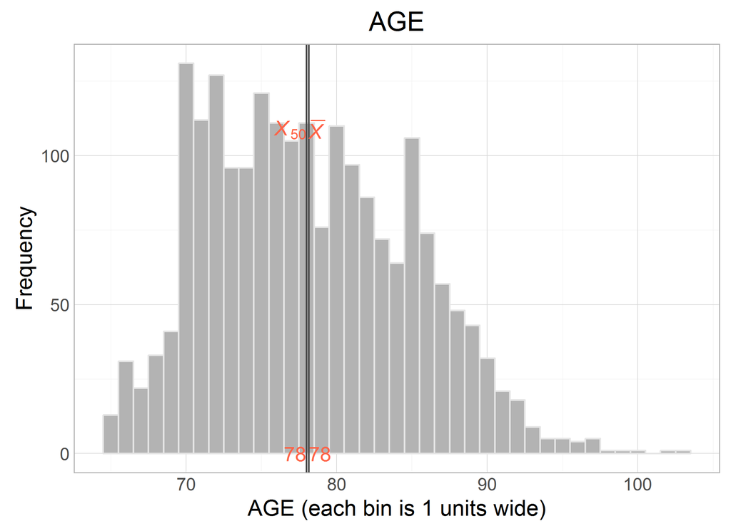

```r
dto[["unitData"]][["alsa"]] %>% histogram_continuous("AGE", bin_width = 1)
```

# LBSL

## AGE94

```r
dto[["metaData"]] %>% dplyr::filter(study_name=="lbsl", name=="AGE94") %>% dplyr::select(name,label)
```

```
   name       label
1 AGE94 Age in 1994
```

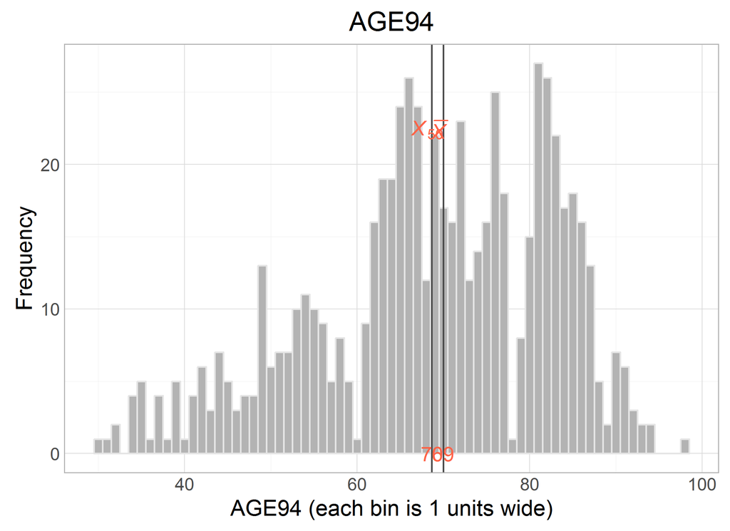

```r
dto[["unitData"]][["lbsl"]] %>% histogram_continuous("AGE94", bin_width = 1)
```

# SATSA

## QAGE3

```r
dto[["metaData"]] %>% dplyr::filter(study_name=="satsa", name=="QAGE3") %>% dplyr::select(name,label)
```

```
   name     label
1 QAGE3 age at Q3
```

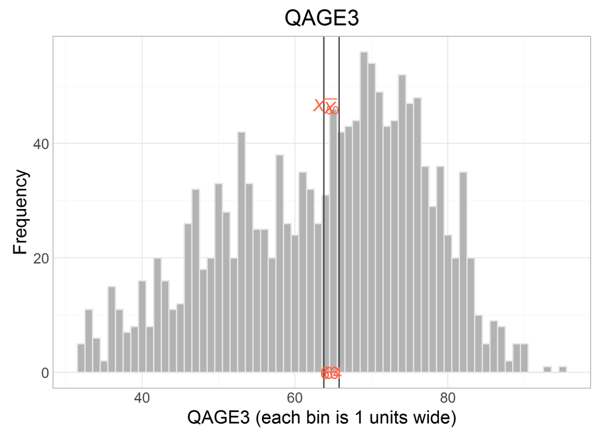

```r
dto[["unitData"]][["satsa"]] %>% histogram_continuous("QAGE3", bin_width = 1)
```

## YRBORN

```r
dto[["metaData"]] %>% dplyr::filter(study_name=="satsa", name=="YRBORN") %>% dplyr::select(name,label)
```

```
    name label
1 YRBORN  <NA>
```

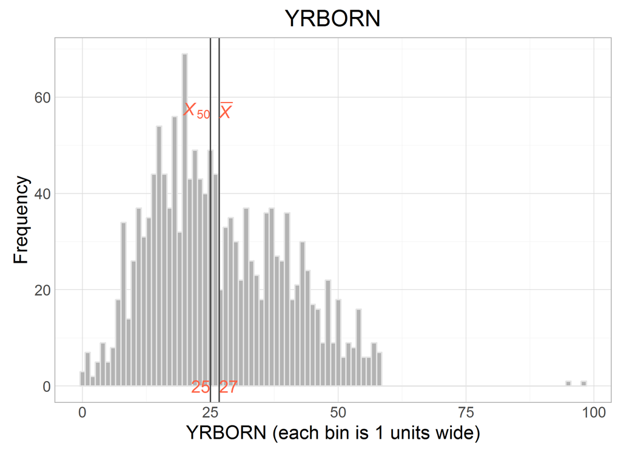

```r
dto[["unitData"]][["satsa"]] %>% histogram_continuous("YRBORN", bin_width = 1)
```

# SHARE

## DN0030

```r
dto[["metaData"]] %>% dplyr::filter(study_name=="share", name=="DN0030") %>% dplyr::select(name,label)
```

```
    name         label
1 DN0030 year of birth
```

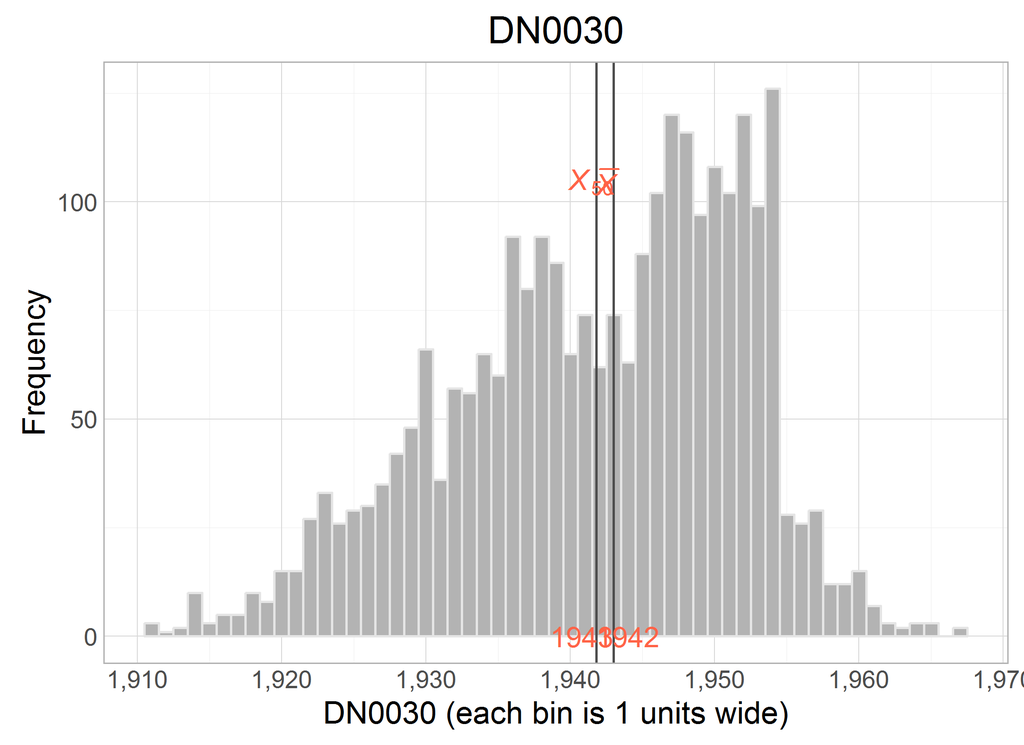

```r
dto[["unitData"]][["share"]] %>% dplyr::filter(!DN0030==99999) %>% histogram_continuous("DN0030", bin_width=1)
```

# TILDA

## AGE

```r
dto[["metaData"]] %>% dplyr::filter(study_name=="tilda", name=="AGE") %>% dplyr::select(name,label)
```

```
  name                                                   label
1  AGE Age at interview assuming DOB is 1st of specified month
```

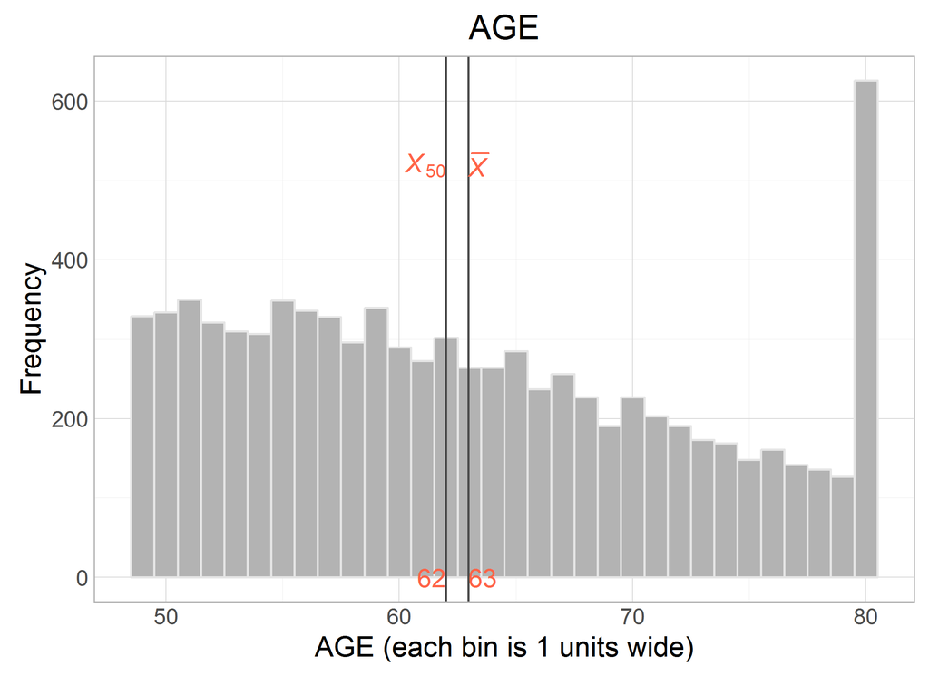

```r
dto[["unitData"]][["tilda"]] %>% histogram_continuous("AGE", bin_width = 1)
```